# Demo: Introduction to R - Distribution Functions

Eleni-Rosalina Andrinopoulou, Department of Biostatistics, Erasmus Medical Center

2022-09-26

# Common probability distributions

- Normal
- $t$
- $\chi^2$
- $F$
- Binomial

# Key functions to describe distributions

- the probability density function always begins with ‘d’ (p.d.f.)
- the cumulative distribution function always begins with ‘p’ (c.d.f.)
- the inverse cumulative distribution (or quantile function) always beings with ‘q’
- a function that produces random variables always begins with ‘r’

## Normal distribution ($z$-distribution)

Plotting a graph with the value of the variable in the horizontal axis and the count of the values in the vertical axis leads to a bell shape curve. We will use the standard normal distribution, given by $\mu = 0$ and $\sigma = 1$.

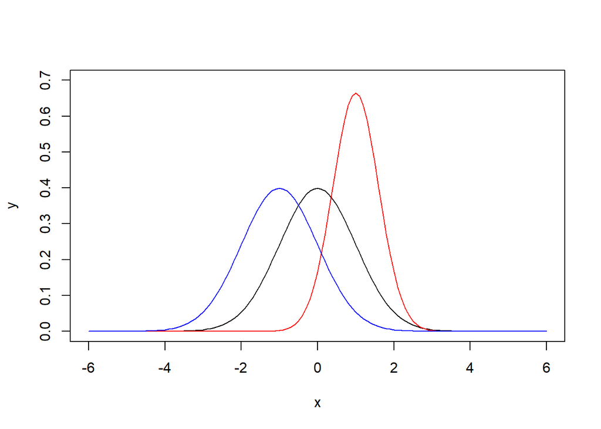

```r
# Create a sequence of numbers between -6 and 6 incrementing by 0.1.
x <- seq(from = -6, to = 6, by = 0.1)


# p.d.f.
y <- dnorm(x = x, mean = 0, sd = 1)
# This function returns the density of the standard normal distribution
# (mean = 0 and sd = 1).

# Let's try other mean and sd.
w <- dnorm(x = x, mean = -1, sd = 1)
z <- dnorm(x = x, mean = 1, sd = 0.6)
# This function returns the density of the standard normal distribution
# for a given mean and standard deviation (p.d.f.).

# Plot
plot(x = x, y = y, type = "l", xlim = c(-6,6), ylim = c(0, 0.7))
lines(x = x, y = z, col = "red")
lines(x = x, y = w, col = "blue")
```

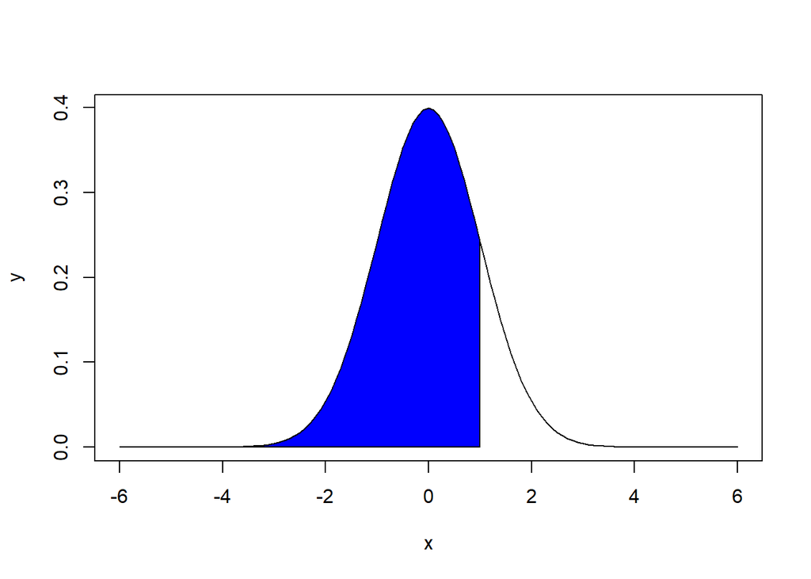

```r
# c.d.f.
y <- pnorm(q = x)
# This function returns the cumulative probability of the standard normal
# distribution.
# That is the area under the standard normal curve to the left of x.
# E.g. for x equal to 1
x <- seq(from = -6, to = 6, by = 0.1)
y <- dnorm(x = x, mean = 0, sd = 1) # Z score
plot(x = x, y = y, type = "l", xlim = c(-6,6))
polygon(x = c(x[x <= 1], 1), y = c(y[x <= 1], 0), col = "blue")
```

```r
# Then:
pnorm(q = 1)
```

```
## [1] 0.8413447
```

```r
# This means that the probability of getting a value smaller or equal
# than 1 is 0.84 or 84%.


# If now we want Pr(X > 1) = 1 - Pr(X <= 1)
1 - pnorm(q = 1)
```

```
## [1] 0.1586553
```

```r
# This means that the probability of getting a value larger than 1 is 0.16 or 16%.

# We can also use the argument lower.tail = FALSE to obtain the same result.
pnorm(q = 1, lower.tail = FALSE)
```

```
## [1] 0.1586553
```

```r
# Inverse cumulative distribution
qnorm(p = 0.84)
```

```
## [1] 0.9944579
```

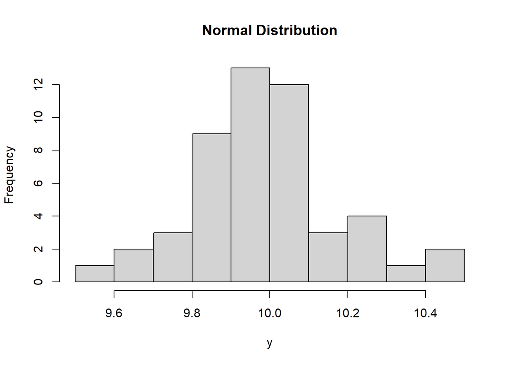

```r
# This function is the inverse of the `pnorm()` function. For example, the X
# score corresponding to the 84th percentile is 1.


#  Random variables
# Create a sample of 50 numbers which are normally distributed with
# mean 10 and sd 0.2.
y <- rnorm(n = 50, mean = 10, sd = 0.2)
# This function is used to generate random numbers whose distribution is normal.
hist(x = y, main = "Normal Distribution")
```

```r
# In many applications, we want to be able to reproduce the results of
# our data analysis. It is then important to use the set.seed(q) function
# to generate the same set of random numbers. Here `q` is an integer.
set.seed(123)
rnorm(n = 5)
```

```
## [1] -0.56047565 -0.23017749  1.55870831  0.07050839  0.12928774
```

```r
# If we run the above code multiple times, we get the same numbers.


# Let's generate 10000 random values from a normal distribution with
# mean 0 and sd = 1.
set.seed(123)
x <- rnorm(n = 10000)
mean(x)
```

```
## [1] -0.002371702
```

```r
sd(x)
```

```
## [1] 0.9986366
```

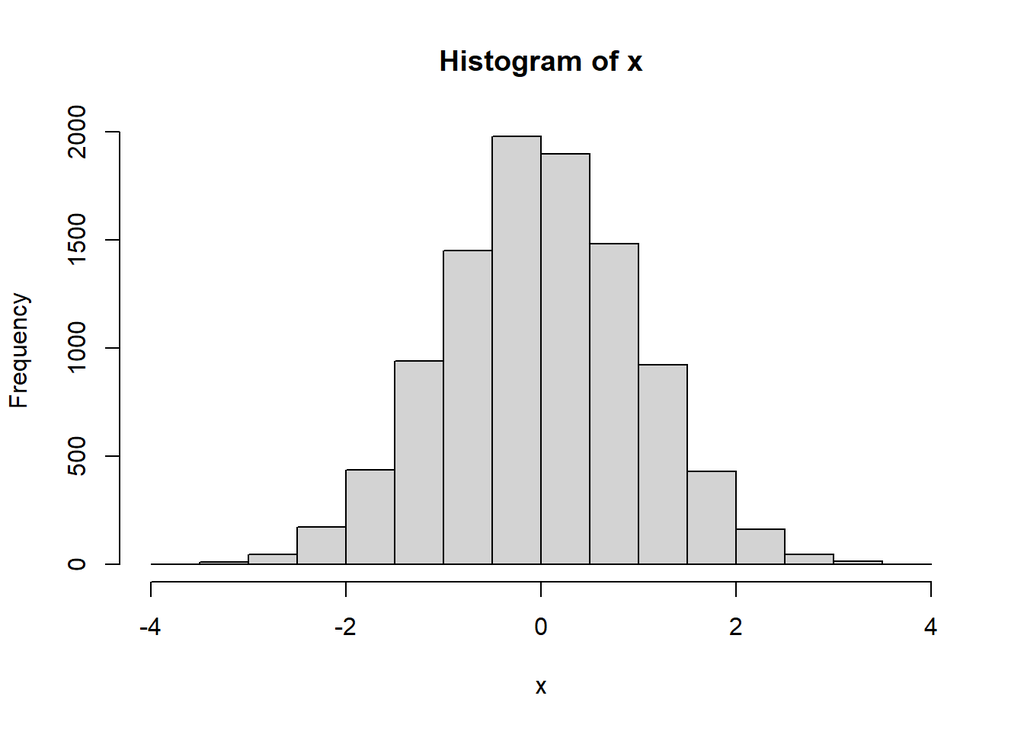

```r
# We see that the mean and sd are very close to 0 and 1 as expected.
# To verify that the data is normally distributed, we generate a histogram
# using the hist().
hist(x = x)
```

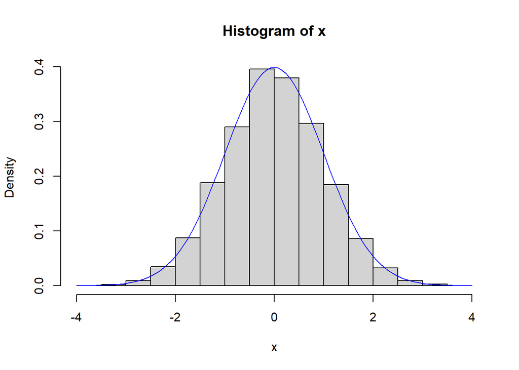

```r
hist(x = x, freq = FALSE)
# The freq = FALSE argument is to obtain the density (fraction of points in
# each interval) on the y-axis instead of frequency (number of points in each
# interval). With this option, the total area of the histogram is normalized to 1.
curve(expr = dnorm(x), col = "blue", add = TRUE)
```

```r
# The function `curve()` draws a curve corresponding to a function.
```

## t-distribution

- Like the normal distribution ($z$-distribution), the t-distribution is also symmetric.
- The $t$-distribution depends on the degrees of freedom. The curves with more degrees of freedom are taller and have thinner tails. These are related to the sample size.
- The $t$-distribution is most useful for small sample sizes, when the population standard deviation is not known, or both.
- As the sample size increases, the $t$-distribution becomes more similar to a normal distribution.

**Degrees of freedom**  
Degrees of freedom of an estimate is the number of values that have the freedom to vary in the data sample. It is not quite the same as the number of items in the sample. For example we are interested in the mean BMI of our students. Let’s assume that we have 50 students. If we also have the mean value, this means that 49 BMI values can vary and 1 has to be fixed. If we have $X_1$, $\dots$, $X_n$, where $n$ is the number of subjects and we know the mean value $\bar{x} = \frac{(X_1 + \dots + X_n)}{n}$, then $X_1$, $\dots$, $X_{n-1}$ can vary but $X_n$ has to be fixed. E.g., suppose we collect two random samples of observations shown below. Let’s assume that we know the mean but we don’t know the value of an observation ($X$ and $Y$). All other values can vary except $X$ and $Y$ in order to get those means. $X$ should be $20$ and $Y$ should be $26$.

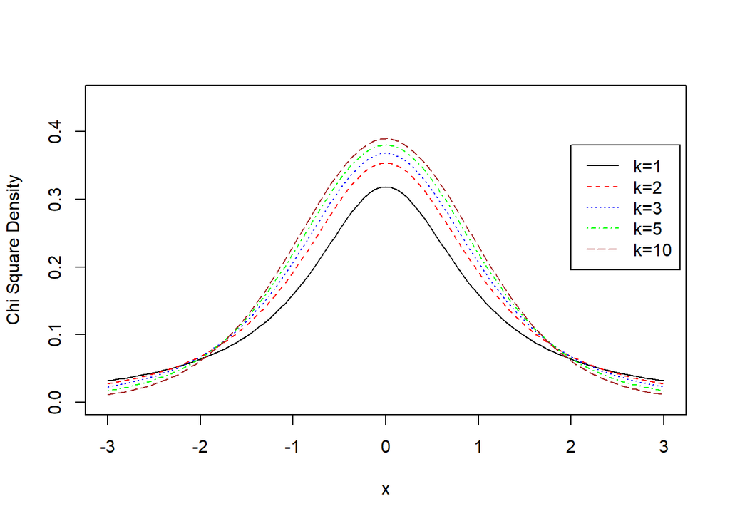

```r
# =========== ========= =========
#              Sample1   Sample2
# =========== ========= =========
#  Subject1      18        19
#  Subject2      15        28
#  Subject3      21        22
#  Subject4      30        18
#  Subject5      22        19
#  Subject6       X         Y
# =========== ========= =========
#  Average       21        22


# Generate a random sample from the standard normal distribution.
x <- rnorm(n = 10000)


# p.d.f.
# For this distribution we need to define the degrees of freedom.
curve(expr = dt(x = x, df = 1), xlim = c(-3, 3), ylim = c(0, 0.45),
      ylab = "Chi Square Density")
curve(expr = dt(x = x, df = 2), col = "red",lty = 2, add = TRUE)
curve(expr = dt(x = x, df = 3), col = "blue",lty = 3, add = TRUE)
curve(expr = dt(x = x, df = 5), col = "green",lty = 4, add = TRUE)
curve(expr = dt(x = x, df = 10), col = "brown",lty = 5, add = TRUE)
legend(2, 0.38, c("k=1", "k=2", "k=3", "k=5", "k=10"),
       col = c("black", "red", "blue", "green", "brown"), lty = 1:5)
```

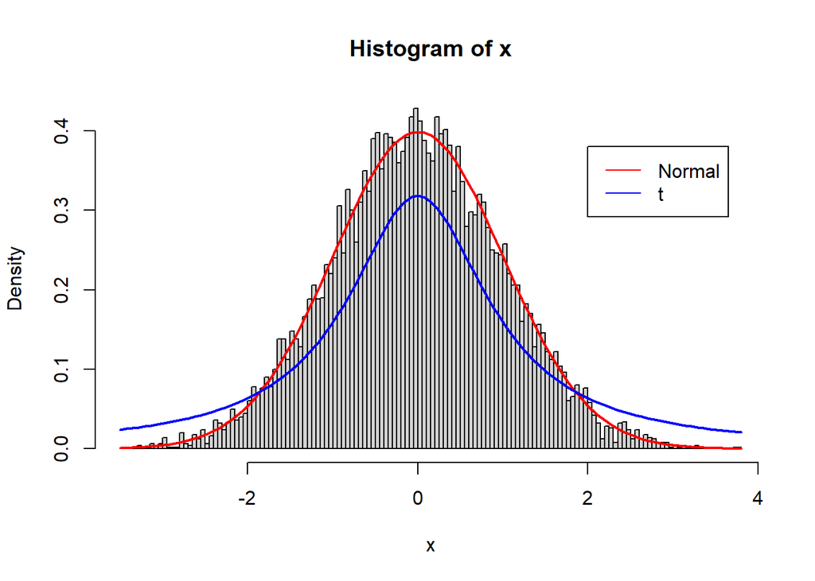

```r
# Difference between normal and $t$ distribution
hist(x, freq = FALSE, breaks = 200)
curve(expr = dnorm(x), col = "red", lwd = 2, add = TRUE)
curve(expr = dt(x = x, df = 1), col = "blue", lwd = 2, add = TRUE)
legend(2, 0.38, c("Normal", "t"),
       col = c("red", "blue"), lty = c(1,1))
```

```r
# c.d.f.
# The `pt()` function returns the cumulative probability of the $t$ distribution.
# E.g. Pr(X <= 1):
pt(q = 1, df = 1)
```

```
## [1] 0.75
```

```r
# This means that the probability of getting a value smaller or equal than
# 1 is 0.75 or 75%.

# If now we want Pr(X > 1) = 1 - Pr(X <= 1)
1 - pt(q = 1, df = 1)
```

```
## [1] 0.25
```

```r
# This means that the probability of getting a value larger than 1 is 0.25 or 25%.

# We can also use the argument lower.tail = FALSE to obtain the same result.
pt(q = 1, df = 1, lower.tail = FALSE)
```

```
## [1] 0.25
```

```r
# Inverse cumulative distribution
qt(p = 0.75, df = 1)
```

```
## [1] 1
```

```r
# This function is the inverse of the `pt()` function.
# For example, the value corresponding to the 75th percentile is 1.

# Random variables
set.seed(123)
x <- rt(n = 10000, df = 3)
```

## $\chi^2$ distribution

A $\chi^2$ distribution with $k$ degrees of freedom is constructed by the sum of the square of $k$ independent standard normal random variables. If $X_1, X_2, \dots, X_k$ are independent random variables from the standard normal distribution, then the random variable $Q = X^2_1+X^2_2+ \dots +X^2_k$ follows the $\chi^2$ distribution with $k$ degrees of freedom.

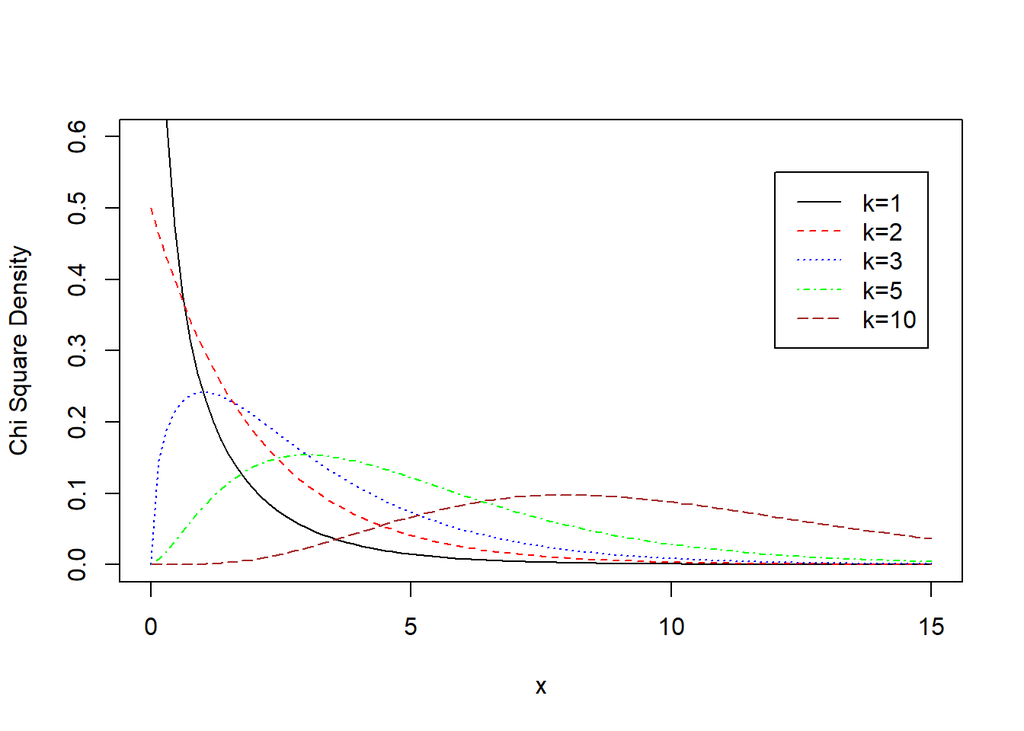

```r
# Generate a random sample from the standard normal distribution.
x <- rnorm(n = 10000)


# p.d.f.
# For this distribution we need to define the degrees of freedom.
curve(expr = dchisq(x = x, df = 1), xlim = c(0, 15), ylim = c(0, 0.6),
      ylab = "Chi Square Density")
curve(expr = dchisq(x = x, df = 2), col = "red",lty = 2, add = TRUE)
curve(expr = dchisq(x = x, df = 3), col = "blue",lty = 3, add = TRUE)
curve(expr = dchisq(x = x, df = 5), col = "green",lty = 4, add = TRUE)
curve(expr = dchisq(x = x, df = 10), col = "brown",lty = 5, add = TRUE)
legend(12, 0.55, c("k=1", "k=2", "k=3", "k=5", "k=10"),
       col=c("black", "red", "blue", "green", "brown"), lty = 1:5)
```

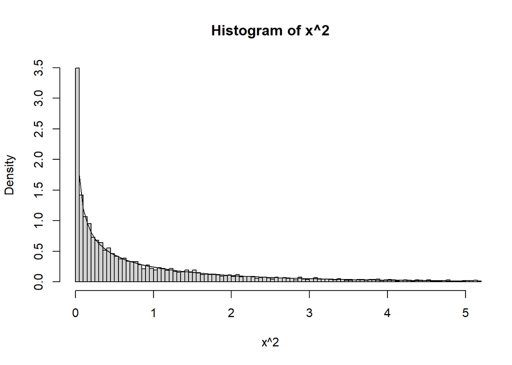

```r
# If we now plot x^2, were x is a random variable from the standard normal
# distribution we get:
hist(x = x^2, freq = FALSE, breaks = 200, xlim = c(0,5))
# Does it look familiar?
curve(expr = dchisq(x = x, df = 1), add = TRUE)
```

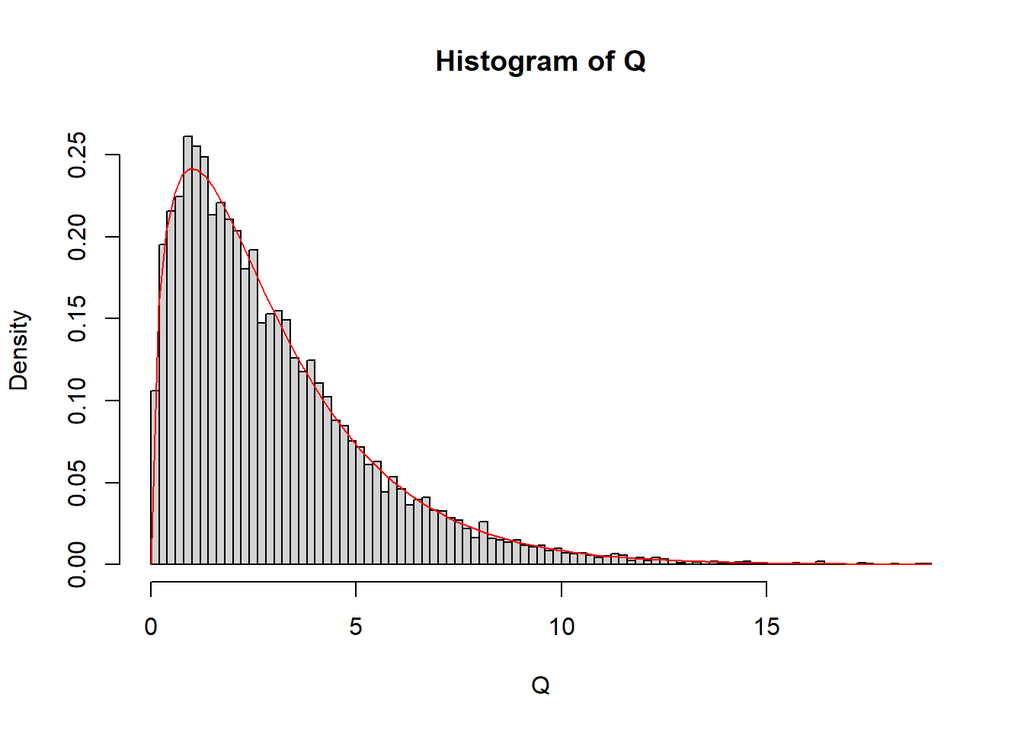

```r
# x^2  follows the \chi^2 distribution with one degree of freedom.


# Let's assume more variables.
X1 <- rnorm(n = 10000)^2
X2 <- rnorm(n = 10000)^2
X3 <- rnorm(n = 10000)^2
Q <- X1 + X2 + X3

hist(Q, freq = FALSE, breaks = 100)
curve(expr = dchisq(x = x, df = 3), col = "red", add = TRUE)
```

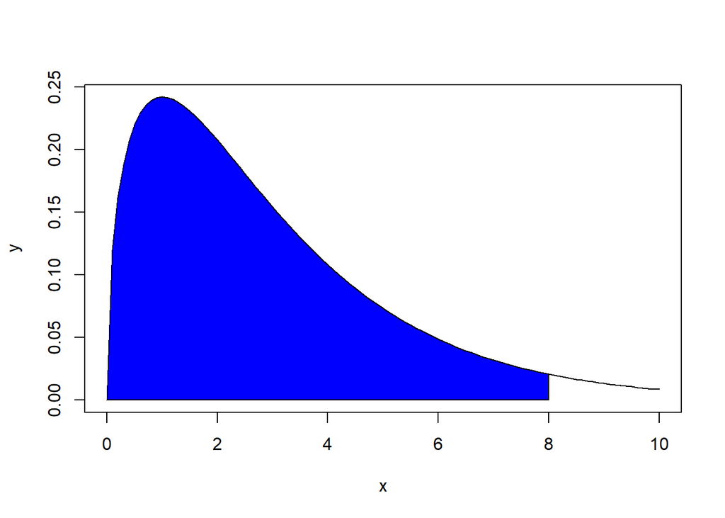

```r
# Random variables
x <- rchisq(n = 10000, df = 3)


# c.d.f.
# Same as before:
x <- seq(from = 0, to = 10, by = 0.1)
y <- dchisq(x = x, df = 3)
plot(x, y, type = "l")
polygon(c(x[x <= 8], 8), c(y[x <= 8], 0), col = "blue")
```

```r
# The Pr(x^2 <= 8) is
pchisq(q = 8, df = 3)
```

```
## [1] 0.9539883
```

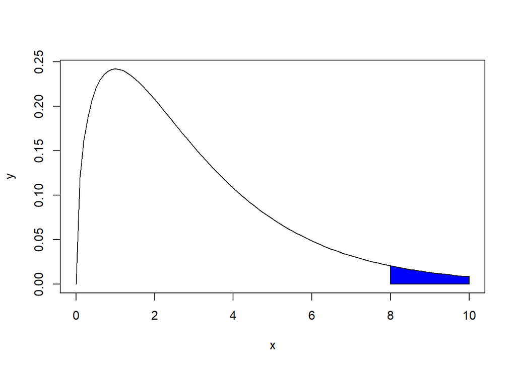

```r
plot(x, y, type = "l")
polygon(c(8, x[x >= 8], max(x)), c(0, y[x >= 8], 0), col = "blue")
```

```r
# The Pr(x^2 > 8) is
pchisq(q = 8, df = 3, lower.tail = FALSE)
```

```
## [1] 0.04601171
```

```r
# Inverse cumulative distribution
qchisq(p = 0.95, df = 3)
```

```
## [1] 7.814728
```

```r
# This function is the inverse of the pchisq() function.
# For example, the value corresponding to the 95th percentile is 8.
```

## $F$ distribution

If two independent random variables follow the $\chi^2$-distribution with m1 and m2 degrees of freedom respectively, then the ratio each divided by its degrees of freedom follows an $F$ distribution. This distribution is used whenever you need to compare two $\chi^2$-distributions (compare two different sum of squares).

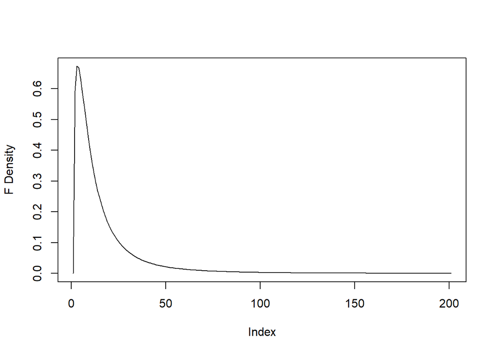

```r
# Generate a sequence of values.
x <- seq(from = 0, to = 20, by = 0.1)


# p.d.f.
plot(df(x = x, df1 = 3, df2 = 5), type = "l", ylab = "F Density")
```

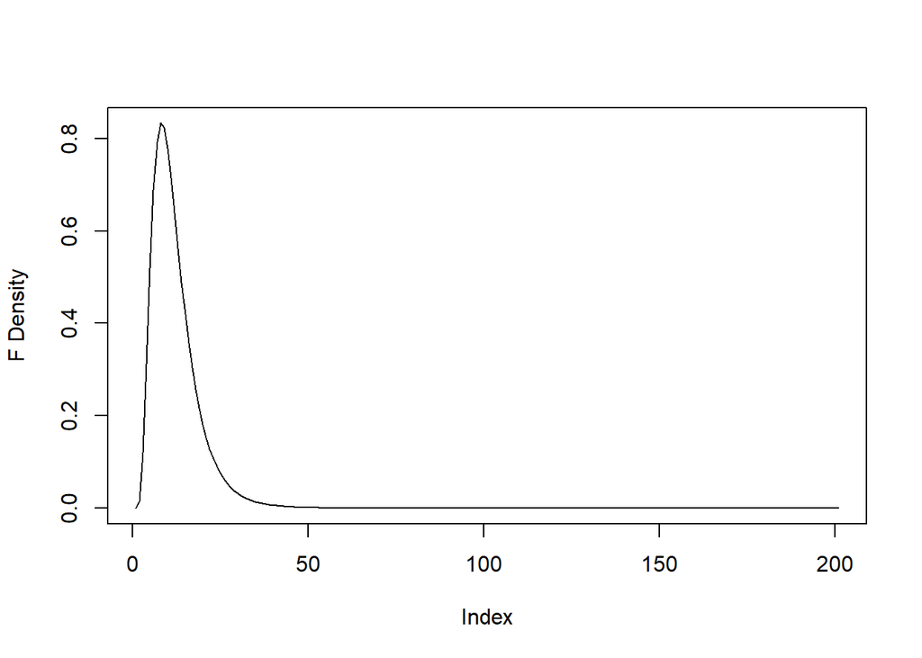

```r
plot(df(x = x, df1 = 10, df2 = 20), type = "l", ylab = "F Density")
```

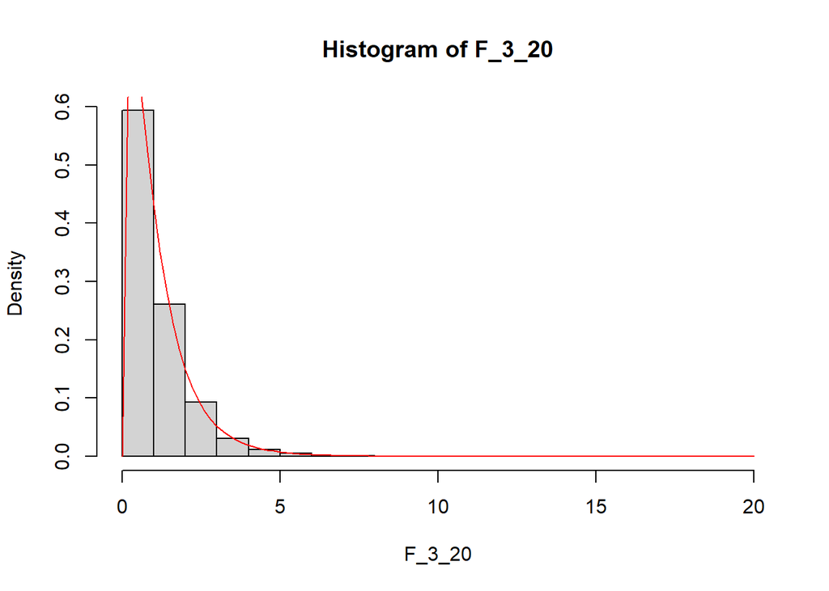

```r
# Generate chi square data with df = 3.
chi.sq.1 <- rchisq(10000, 3)
# Scale the chi square variable.
scaled.chi.sq.1 <- chi.sq.1 / 3
# Generate chi square data with df = 20.
chi.sq.2 <- rchisq(10000, 20)
# Scale the chi square variable.
scaled.chi.sq.2 <- chi.sq.2 / 20
# Take the ratio of the two chi squares (F).
F_3_20 <-  scaled.chi.sq.1  / scaled.chi.sq.2
# Plot
hist(F_3_20, freq = FALSE)
curve(expr = df(x = x, df1 = 3, df2 = 20), col = "red", add = TRUE)
```

## Binomial

The binomial distribution model deals with finding the probability of success of an event which has only two possible outcomes in a series of experiments. For example, tossing a coin always gives a head or a tail. The probability of finding exactly 3 heads in tossing a coin repeatedly for 10 times is estimated using the binomial distribution.  
Note: A single success/failure experiment is also called a Bernoulli trial or a Bernoulli experiment.

```r
# Create a sample of 50 numbers ranging from 0 to 50 which are incremented by 1.
x <- seq(from = 0, to = 50, by = 1)


# p.d.f.
# Here we need to define the number of trials (size) and the probability of
# success on each trial (prob).
y <- dbinom(x, size = 50, prob = 0.5, log = FALSE)


# c.d.f.
y <- pbinom(q = x, size = 50, prob = 0.5)
# This function returns the cumulative probability function of the
# binomial distribution.

# Assume a coin is weighted so that it comes up heads 60% of the time.
# What is the probability that you will obtain more than 25 heads after 50 flips?
# Pr(X > 25) = 1 - Pr(X <= 25)
1 - pbinom(q = 25, size = 50, prob = 0.6)
```

```
## [1] 0.9021926
```

```r
# other way to obtain the same results
1 - sum(dbinom(x = (1:25), size = 50, prob = 0.6))
```

```
## [1] 0.9021926
```

```r
# Alternatively,
pbinom(q = 25,  size = 50, prob = 0.6, lower.tail = FALSE)
```

```
## [1] 0.9021926
```

```r
# Assume a die is rolled 10 times. What it the probability that you will roll
# fewer than 5 sixes?
# Pr(X < 5) = Pr(X <= 4)
pbinom(q = 4, size = 10, prob = 0.16)
```

```
## [1] 0.9869899
```

```r
# Assume a die is rolled 100 times.
# What it the probability that you will roll more than 5 sixes?
# Pr(X > 5) = 1 - Pr(X <= 5)
1 - pbinom(q = 5, size = 100, prob = 0.16, lower.tail = TRUE)
```

```
## [1] 0.9993208
```

```r
pbinom(q = 5, size = 100, prob = 0.16, lower.tail = FALSE)
```

```
## [1] 0.9993208
```

```r
# Random variables
x <- rbinom(n = 20, size = 1, prob = 0.3)
print(x)
```

```
##  [1] 0 0 0 0 0 0 1 1 0 0 1 0 0 0 0 1 0 0 1 0
```